# investigate the exponential distribution in R and compare it with the Central Limit Theorem

ismael

2022-09-21

## Overview

In this project you will investigate the exponential distribution in R and compare it with the Central Limit Theorem. The exponential distribution can be simulated in R with rexp(n, lambda) where lambda is the rate parameter. The mean of exponential distribution is 1/lambda and the standard deviation is also 1/lambda. Set lambda = 0.2 for all of the simulations. You will investigate the distribution of averages of 40 exponentials. Note that you will need to do a thousand simulations.

## Simulations

Illustrate via simulation and associated explanatory text the properties of the distribution of the mean of 40 exponentials

Run Simulations with variables

#### Calculate Sample Mean

Calculating the mean from the simulations with give the sample mean.

```
## [1] 4.990025
```

#### Calculate Theoretical Mean

Calculating the theoretical mean of an exponential distribution (lambda^-1).

```
## [1] 5
```

#### Comparison of means

Sample Mean and Theoretical Mean are almost the same

```
## [1] 0.009974799
```

#### Calculate Sample Variance

Calculating the variance from the simulation means with give the sample variance.

```
## [1] 0.6111165
```

#### Calculate Theoretical Variance

The theoretical variance of an exponential distribution is (lambda * sqrt(n))^-2.

```
## [1] 0.625
```

#### Comparison of Variances

Sample Variance and Theoretical Variance are almost the same

```
## [1] 0.01388353
```

## Distribution

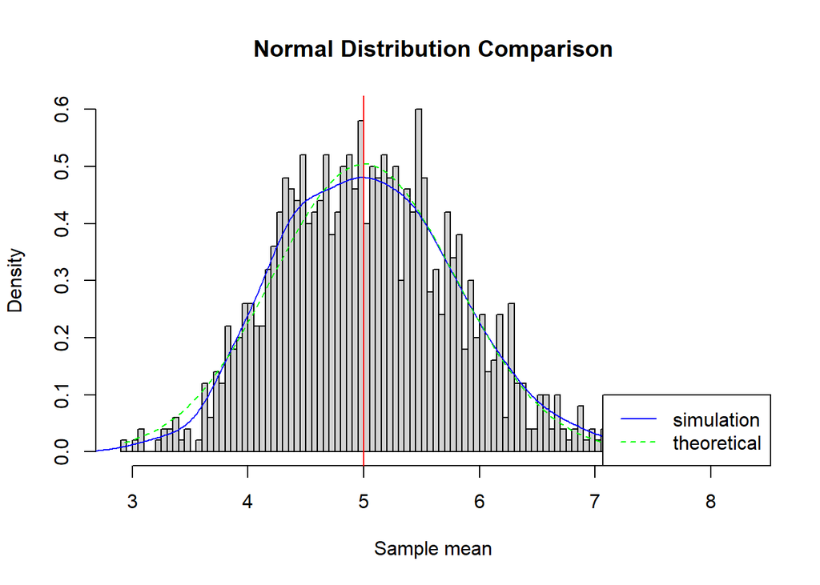

```r
simnum <- 1000
sim <- matrix(rexp(simnum*exponentials, rate=lambda), simnum, exponentials)
row_means <- rowMeans(sim)
# plot of histogram of means
hist(row_means, breaks=100, prob=TRUE,
     main="Normal Distribution Comparison", xlab="Sample mean")
# density of the means of samples
lines(density(row_means), col="blue")
# theoretical center of distribution
abline(v=1/lambda, col="red")
# theoretical density of the means of samples
xfit <- seq(min(row_means), max(row_means), length=100)
yfit <- dnorm(xfit, mean=1/lambda, sd=(1/lambda/sqrt(exponentials)))
lines(xfit, yfit, pch=22, col="green", lty=2)
# add legend
legend('bottomright', c("simulation", "theoretical"), lty=c(1,2), col=c("blue", "green"))
```

Due to the Central Limit Theorem, the distribution of means of the sampled exponential distributions follow a normal distribution.